# NEUROHACK 2022

## Team

[figure not shown]

### Members

```r
members <- readxl::read_excel("presentations/team_members.xlsx")
DT::datatable(members)
```

|  | Name | Affiliation | Expertise | Roles |
| --- | --- | --- | --- | --- |
| 1 | Brian Schilder | Imperial College London | Bioinformatics Evolutionary biology Neuroscience Machine learning GWAS summary statistics Fine-mapping eQTL colocalization Matrix decomposition Single-cell RNA-seq R, Python, web dev | Team lead. SV/SNP/Indel data preprocessing (variant and gene levels). Presentation creation/presenting. |
| 2 | Yizhou Yu | University of Cambridge | Bioinfo Wet lab (cell culture) ML SNP data Molecular modelling / virtual drug screening / structural bio | Preprocessing of functional impact predictions from deep learning models (DeepSEA, Basenj). Virtual drug screening. |
| 3 | Hanz Tantiangco | University of Sheffield | Computational chemistry Drug discovery Deep learning (Pytorch) Neuroscience (some) bioinformatics Python, R | Assist in classifier model design. Explore dimensionality reduction/feature prioritization pre-step with PCA and autencoder. |
| 4 | Areda Elezi | Crick Institute | Bioinformatics Nexflow pipelines (RNAseq etc) Web and software dev Wet lab Basic ML Python | Search for additional data modalities. Prepare Expansion Hunter script. |
| 5 | Siddharth Grover | Indian Institute of Technology | Machine Learning Data Mining Python, C++ | Assist in classifier model design. |
| 6 | Davide Spalla | Donders Institute | Machine learning Neuroscience Python Data analysis/visualization | Design and train classifier model. |
| 7 | Guan Wang | University of Brighton | GWAS analysis Bulk RNA-seq data analysis (short-reads) Population genetics; genomics | Preprocess combined SNP-to-gene model (cS2G) data. |
| 8 | Renata Kabiljo | King’s College London | NGS Data Analysis Python, R General Bioinformatics | Generate and preprocess retroviral insertion predictions. |

### Project title

Predicting ALS drug targets using integrative multi-modal machine learning

### Goals

1. Identify molecular targets (genes and variants) of ALS (status and survival time).
2. Identify potential therapeutics for ALS.

### Workflow

1. Preprocess input datasets
   - MND_ALS VCFs
   - External datasets
2. Filter input features
3. Train predictive model
4. Extract key genes
5. Identify therapeutics

## Materials

The following datatypes were prepared as numeric participant x feature matrices that could be fed into our machine learning model.

### Phenotypes

Participant x phenotype data for each of the 20 ALS participants were encoded as numeric vectors and fed as input to the model. This currently only include sex, but can easily be expanded to other categorical or continuous traits as they become available.

### Retroviral insertions

Retroviral insertions were identified using the pipeline described [here](https://github.com/DEMON-NEUROHACK/Challenge-3-London-Team-C/blob/main/data/HERVK_Insertions/readme.md).

### SNPs: variant-level

### SNPs: gene-level

### Indels: variant-level

### SVs: variant-level

### SVs: gene-level

## Methods

### Dimensionality reduction model

**Figure 1.**:

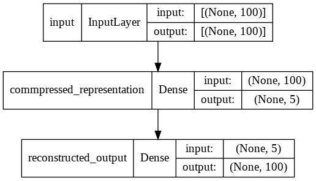

### Classifier moel

Each input modality (datatype) was fed into an supervised fully-connected artificial neural network (ANN), such that each participant is a sample and each gene/variant/annotation is a feature. The inputs of the model are initially partitioned into separate “channels” of the model input, and are reduced in dimensionality by the subsequent layers. Next, the reduced representation from each modality are concatenated into a single vector (layer 3 in **Fig. 2** below). Finally, the data is further compressed to predict which phenotypic category each participant belongs to.

The model is currently designed to provide categorical predictions for each sample: short-survival vs. long-survival, or ALS vs. control (depending on the data available). However, it can also easily be adapted to continuous phenotypic data (e.g. survival years, GWAS-derived polygenic risk score (PRS)).

Once fully trained, the model can be interrogated to extract the most relevant features per modality. This allows us to generate ranked lists of genes/variants/annotations which can be used in the candidate therapeutics prediction step.

**Figure 2**:

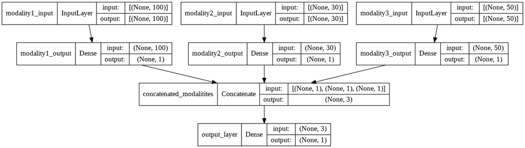

### Therapeutics prediction

Once the relative importance of each gene for predicting ALS survival have been identified, three complementary approaches will be used to identify candidate therapeutics for ALS: 1. virtual screening, 2. perturbation database queries, 3. literature mining.

## Conclusions

## Future directions

# File descriptions

## [data/SNP_VCFs/](https://github.com/DEMON-NEUROHACK/Challenge-3-London-Team-C/tree/main/data/SNP_VCFs)

### by_variant/

### SNP_VCFs.all.tsv.gz

All 20 MND ALS dummy VCFs from *SNP_VCFs/* merged into one participant x variant matrix.

The matrix is filled with genotypes numerically encoded as detailed [here](https://github.com/DEMON-NEUROHACK/Challenge-3-London-Team-C/blob/main/data/genotype_encodings.csv).

### SNP_VCFs.merged.tsv.gz

All 20 MND ALS dummy VCFs from *SNP_VCFs/* merged into a `data.table` in long-format.

This is the data from which *SNP_VCFs.all.tsv.gz* is derived.

## [data/HERVK_Insertions/](https://github.com/DEMON-NEUROHACK/Challenge-3-London-Team-C/tree/main/data/HERVK_Insertions)

### HERV_K_Insertions.txt

A dummy file with HERV_K insertions for all 20 MND ALS dummy subjects.

## References

> van Rheenen, W., van der Spek, R.A.A., Bakker, M.K. et al. Common and rare variant association analyses in amyotrophic lateral sclerosis identify 15 risk loci with distinct genetic architectures and neuron-specific biology. Nat Genet 53, 1636–1648 (2021). https://doi.org/10.1038/s41588-021-00973-1